# Modeling - Chronic diseases

Anaïs Ladoy

2023-04-09

### Import the datasets

- `data`: All F2 Colaus participants eligible for this study (see selection procedure).
- `env`: Neighborhood characteristics build in **explore_neighborhood_characteristics.Rmd**
- `boundary.laus`: Boundary of the Lausanne area (polygon)
- `boundary.vd`: Boundary of the Vaud state (polygon)
- `predict.grid`: Prediction grid for Vaud state (inhabited hectares only)

```r
cov.indiv <- c("age", "sex", "swiss", "cohabiting", "education", "working", "difficulties", "smoking", "drinking", "inactivity", "out_laus")

cov.env <- c("PTOT", "D_SPORT", "N_ACC_PED", "GREEN_SP", "ENV_INDEX", "SOC_ECO_INDEX", "SWISS", "UNEMPLOYMENT", "LOW_EDUC", "INCOME", "HH_1PERS")

cov.continuous <- c("age", cov.env)
# "F_45_54", "F_55_64", "F_65_74", "F_75_MORE", "M_45_54", "M_55_64", "M_65_74", "M_75_MORE"
```

I removed HIGH_EDUC because highly correlated with LOW_EDUC in the model but the spatial pattern is different (see spatial_clustering_outcomes). Should I include both? Same for poverty and income. Easier to predict with a binary variable but we loose some granularity and both are correlated. What should we keep in the model? For now, I kept income.

# Diabetes

```r
diab.data <- select_outcome(data, "diabetes", cov.indiv, cov.env)
```

```
## [1] "Outcome selected:  diabetes"
## [1] "Prevalence:  9.58"
```

Distribution of age and neighborhood-related characteristics between cases and controls.

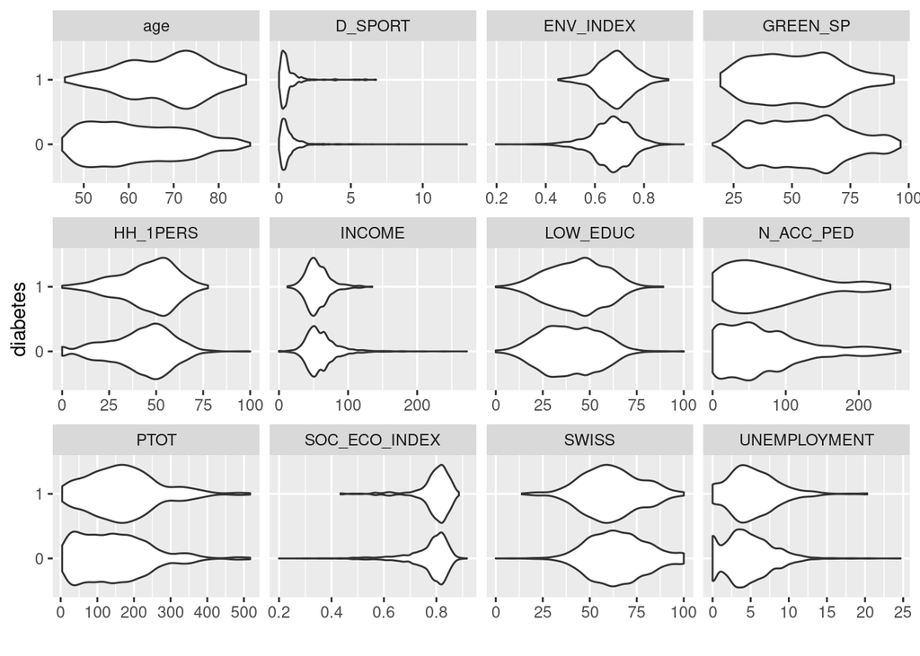

```r
plot_cov_distribution(diab.data, "diabetes", cov.continuous)
```

Split dataset (train + test)

```r
diab.subset <- create_train_dataset(diab.data, frac=0.8, seed=12345)
```

```
## [1] 12345
```

### 1. Investigate the individual-level covariates using a logistic regression

**Generalized Linear Model using the train dataset (80%)**

```r
m.univ <- glm(diabetes ~ sex, data=diab.subset$train, family='binomial')
print_model_summary(m.univ)
```

```
##
## Call:
## glm(formula = diabetes ~ sex, family = "binomial", data = diab.subset$train)
##
## Deviance Residuals:
##     Min       1Q   Median       3Q      Max
## -0.5719  -0.5719  -0.3583  -0.3583   2.3570
##
## Coefficients:
##             Estimate Std. Error z value Pr(>|z|)
## (Intercept) -1.72795    0.07436  -23.24  < 2e-16 ***
## sexW        -0.98549    0.12302   -8.01 1.14e-15 ***
## ---
## Signif. codes:  0 '***' 0.001 '**' 0.01 '*' 0.05 '.' 0.1 ' ' 1
##
## (Dispersion parameter for binomial family taken to be 1)
##
##     Null deviance: 2097.4  on 3196  degrees of freedom
## Residual deviance: 2029.5  on 3195  degrees of freedom
## AIC: 2033.5
##
## Number of Fisher Scoring iterations: 5
##
## McFadden criteria (Likelihood ratio test): 0.03239
```

```
##                    OR     2.5 %    97.5 %
## (Intercept) 0.1776480 0.1531651 0.2050263
## sexW        0.3732563 0.2924771 0.4739478
```

- `Deviance residuals`: should be centered around 0 and symmetrical.
- `Coefficients`: give the log-odds estimates. Effect size.
- `Dispersion parameter`: since the variance is derived from the estimated mean (compared to the linear regression where we estimate both the mean and the variance from the data), it can be underestimated and we can adjust this by adjusting the dispersion parameter.
- `Null and Residual Deviance`: can be used to compare models, compute R^2 and an overall p-value.
- `AIC`: Akaike Information Criterion, which is here the residual deviance adjusted for the number of parameters in the model. Can be used to compare models.
- `Fisher Scoring Iterations`: how quickly the glm() function converged on the maximum likelihood estimates for the coefficients.

*Compare models:* Better model will have lower residual deviance and lower AIC.  
*Specification error*: we must particularly check here if our model has all relevant predictors, and if the linear combinations of them is sufficient.

```r
paste("The probability that a man has diabetes is", inverse_logit(m.univ$coefficients[[1]]))
```

```
## [1] "The probability that a man has diabetes is 0.15"
```

```r
paste("The probability that a woman has diabetes is", inverse_logit(m.univ$coefficients[[1]] + m.univ$coefficients[[2]]))
```

```
## [1] "The probability that a woman has diabetes is 0.06"
```

```r
paste("Women are", round(1/exp(m.univ$coefficients[[2]]),2), "less likely to have diabetes than a man.")
```

```
## [1] "Women are 2.68 less likely to have diabetes than a man."
```

```r
mcfadden(m.univ)
```

```
## McFadden criteria (Likelihood ratio test): 0.03239
```

**Investigate individual-level covariates using a backward stepwise logistic regression.**

```r
glm.indiv <- stepwise_logistic_regression(diab.subset$train, "diabetes", cov.indiv, trace=0)
```

```
##
## Call:
## glm(formula = diabetes ~ age + sex + swiss + education + working +
##     difficulties + smoking + inactivity + out_laus, family = binomial(),
##     data = data)
##
## Deviance Residuals:
##     Min       1Q   Median       3Q      Max
## -1.3774  -0.4873  -0.3359  -0.2152   3.0908
##
## Coefficients:
##                  Estimate Std. Error z value Pr(>|z|)
## (Intercept)     -5.393885   0.618003  -8.728  < 2e-16 ***
## age              0.047826   0.008066   5.929 3.04e-09 ***
## sexW            -1.318518   0.131313 -10.041  < 2e-16 ***
## swiss1          -0.203145   0.131698  -1.543  0.12295
## educationLow     0.772515   0.190846   4.048 5.17e-05 ***
## educationMedium  0.422097   0.215099   1.962  0.04972 *
## working1        -0.456499   0.168954  -2.702  0.00689 **
## difficulties1    0.573429   0.138039   4.154 3.27e-05 ***
## smoking1         0.334584   0.142834   2.342  0.01916 *
## inactivity1      0.503885   0.126790   3.974 7.06e-05 ***
## out_laus1       -0.341245   0.185119  -1.843  0.06527 .
## ---
## Signif. codes:  0 '***' 0.001 '**' 0.01 '*' 0.05 '.' 0.1 ' ' 1
##
## (Dispersion parameter for binomial family taken to be 1)
##
##     Null deviance: 2097.4  on 3196  degrees of freedom
## Residual deviance: 1822.1  on 3186  degrees of freedom
## AIC: 1844.1
##
## Number of Fisher Scoring iterations: 6
##
## McFadden criteria (Likelihood ratio test): 0.13127
```

```
##                          OR       2.5 %     97.5 %
## (Intercept)     0.004544283 0.001336398 0.01508153
## age             1.048988081 1.032627834 1.06581290
## sexW            0.267531390 0.206192849 0.34514123
## swiss1          0.816159951 0.631101965 1.05800278
## educationLow    2.165205569 1.504856427 3.18546874
## educationMedium 1.525156206 1.005849681 2.34237019
## working1        0.633497705 0.454365305 0.88144507
## difficulties1   1.774340073 1.350939620 2.32181746
## smoking1        1.397358303 1.052576193 1.84357429
## inactivity1     1.655138186 1.292972711 2.12625389
## out_laus1       0.710884988 0.488602877 1.01128119
```

**Test if we should model age as non-linear to diabetes (with cubic spline)**

```r
gam.indiv <- mgcv::gam(diabetes ~ s(age, bs="cr") + sex + swiss + education + working + difficulties + smoking + inactivity + out_laus, method = "GCV.Cp", data=diab.subset$train, family="binomial")
print_model_summary(gam.indiv, type="gam")
```

```
##
## Family: binomial
## Link function: logit
##
## Formula:
## diabetes ~ s(age, bs = "cr") + sex + swiss + education + working +
##     difficulties + smoking + inactivity + out_laus
##
## Parametric coefficients:
##                 Estimate Std. Error z value Pr(>|z|)
## (Intercept)      -2.4809     0.2341 -10.596  < 2e-16 ***
## sexW             -1.3211     0.1312 -10.067  < 2e-16 ***
## swiss1           -0.1951     0.1319  -1.479 0.139264
## educationLow      0.7768     0.1911   4.065 4.80e-05 ***
## educationMedium   0.4325     0.2152   2.010 0.044469 *
## working1         -0.3807     0.1691  -2.252 0.024343 *
## difficulties1     0.6013     0.1386   4.337 1.45e-05 ***
## smoking1          0.3274     0.1432   2.287 0.022192 *
## inactivity1       0.4866     0.1270   3.831 0.000128 ***
## out_laus1        -0.3394     0.1858  -1.827 0.067737 .
## ---
## Signif. codes:  0 '***' 0.001 '**' 0.01 '*' 0.05 '.' 0.1 ' ' 1
##
## Approximate significance of smooth terms:
##          edf Ref.df Chi.sq p-value
## s(age) 2.647  3.314  44.28  <2e-16 ***
## ---
## Signif. codes:  0 '***' 0.001 '**' 0.01 '*' 0.05 '.' 0.1 ' ' 1
##
## R-sq.(adj) =  0.098   Deviance explained = 13.9%
## UBRE = -0.42735  Scale est. = 1         n = 3197
## McFadden criteria (Likelihood ratio test): 0.1392
##     (Intercept)            sexW          swiss1    educationLow educationMedium
##      0.08366634      0.26682951      0.82278318      2.17460984      1.54116471
##        working1   difficulties1        smoking1     inactivity1       out_laus1
##      0.68336148      1.82445878      1.38734681      1.62682442      0.71222501
##        s(age).1        s(age).2        s(age).3        s(age).4        s(age).5
##      0.72051164      1.03654276      1.59059469      1.99910098      2.61743084
##        s(age).6        s(age).7        s(age).8        s(age).9
##      3.23237390      2.80753414      2.40119065      1.89019190
```

```r
compare_models(glm.indiv, gam.indiv)
```

```
## [1] "AIC: Model 1 (1844.09425), Model 2 (1830.75294)"
## McFadden criteria (Likelihood ratio test): 0.13127
## McFadden criteria (Likelihood ratio test): 0.1392
## [1] "McFadden's Pseudo-R2: Model 1 (), Model 2 ()"
```

```
## Analysis of Deviance Table
##
## Model 1: diabetes ~ age + sex + swiss + education + working + difficulties +
##     smoking + inactivity + out_laus
## Model 2: diabetes ~ s(age, bs = "cr") + sex + swiss + education + working +
##     difficulties + smoking + inactivity + out_laus
##   Resid. Df Resid. Dev     Df Deviance  Pr(>Chi)
## 1    3186.0     1822.1
## 2    3184.4     1805.5 1.6466   16.635 0.0001447 ***
## ---
## Signif. codes:  0 '***' 0.001 '**' 0.01 '*' 0.05 '.' 0.1 ' ' 1
```

Model age with a non-linear function significantly improved the model with individual covariates only.

**Plot the cubic splines used to model the diabetes-age relationship**

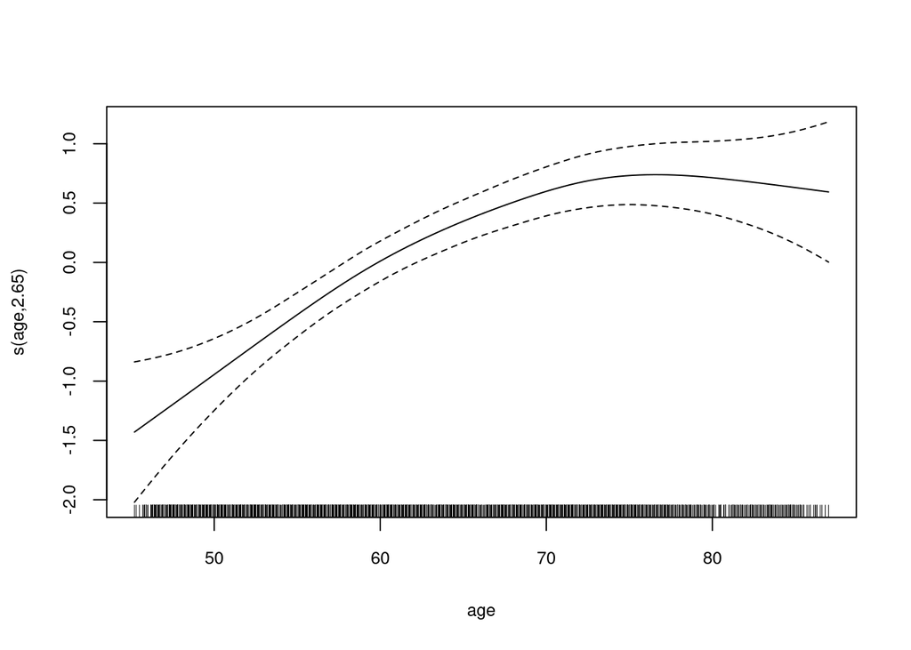

```r
plot(gam.indiv, cex.lab=0.8, cex.axis=0.8)
```

**Try a reduced form by removing individual covariates that were not significant**

```r
gam.indiv.reduced <- update(gam.indiv, diabetes ~ . - swiss - out_laus, method = "GCV.Cp", data=diab.subset$train, family="binomial")
print_model_summary(gam.indiv.reduced, type="gam")
```

```
##
## Family: binomial
## Link function: logit
##
## Formula:
## diabetes ~ s(age, bs = "cr") + sex + education + working + difficulties +
##     smoking + inactivity
##
## Parametric coefficients:
##                 Estimate Std. Error z value Pr(>|z|)
## (Intercept)      -2.6627     0.2175 -12.242  < 2e-16 ***
## sexW             -1.3099     0.1310  -9.998  < 2e-16 ***
## educationLow      0.7618     0.1910   3.989 6.63e-05 ***
## educationMedium   0.4135     0.2149   1.924 0.054303 .
## working1         -0.3766     0.1695  -2.222 0.026257 *
## difficulties1     0.6327     0.1372   4.612 3.99e-06 ***
## smoking1          0.3365     0.1428   2.356 0.018464 *
## inactivity1       0.4871     0.1269   3.840 0.000123 ***
## ---
## Signif. codes:  0 '***' 0.001 '**' 0.01 '*' 0.05 '.' 0.1 ' ' 1
##
## Approximate significance of smooth terms:
##          edf Ref.df Chi.sq p-value
## s(age) 2.705  3.386  46.38  <2e-16 ***
## ---
## Signif. codes:  0 '***' 0.001 '**' 0.01 '*' 0.05 '.' 0.1 ' ' 1
##
## R-sq.(adj) =  0.0962   Deviance explained = 13.6%
## UBRE = -0.42678  Scale est. = 1         n = 3197
## McFadden criteria (Likelihood ratio test): 0.13648
##     (Intercept)            sexW    educationLow educationMedium        working1
##      0.06976055      0.26984255      2.14210699      1.51211879      0.68616360
##   difficulties1        smoking1     inactivity1        s(age).1        s(age).2
##      1.88273232      1.40002907      1.62766077      0.71908822      1.04573210
##        s(age).3        s(age).4        s(age).5        s(age).6        s(age).7
##      1.61713943      2.02857460      2.65453296      3.29435223      2.85545964
##        s(age).8        s(age).9
##      2.42779214      1.89290798
```

```r
compare_models(gam.indiv, gam.indiv.reduced)
```

```
## [1] "AIC: Model 1 (1830.75294), Model 2 (1832.56894)"
## McFadden criteria (Likelihood ratio test): 0.1392
## McFadden criteria (Likelihood ratio test): 0.13648
## [1] "McFadden's Pseudo-R2: Model 1 (), Model 2 ()"
```

```
## Analysis of Deviance Table
##
## Model 1: diabetes ~ s(age, bs = "cr") + sex + swiss + education + working +
##     difficulties + smoking + inactivity + out_laus
## Model 2: diabetes ~ s(age, bs = "cr") + sex + education + working + difficulties +
##     smoking + inactivity
##   Resid. Df Resid. Dev      Df Deviance Pr(>Chi)
## 1    3183.7     1805.5
## 2    3185.6     1811.2 -1.9279  -5.6985  0.05401 .
## ---
## Signif. codes:  0 '***' 0.001 '**' 0.01 '*' 0.05 '.' 0.1 ' ' 1
```

**Select the best model for individual-covariates only**

```r
m.indiv <- gam.indiv
diab.cov.indiv <- c("age", "sex", "swiss", "education", "working", "difficulties", "smoking", "inactivity", "out_laus")
```

### 2.Assess the impact of the environment at the individual level

With socio-eco / environment and without demographic characteristics

```r
glm.env <- stepwise_logistic_regression(diab.subset$train, "diabetes", c(diab.cov.indiv, cov.env), trace=0)
```

```
##
## Call:
## glm(formula = diabetes ~ age + sex + education + working + difficulties +
##     smoking + inactivity + GREEN_SP + UNEMPLOYMENT + LOW_EDUC,
##     family = binomial(), data = data)
##
## Deviance Residuals:
##     Min       1Q   Median       3Q      Max
## -1.5791  -0.4804  -0.3300  -0.2129   3.0927
##
## Coefficients:
##                  Estimate Std. Error z value Pr(>|z|)
## (Intercept)     -5.722651   0.671683  -8.520  < 2e-16 ***
## age              0.048170   0.007972   6.042 1.52e-09 ***
## sexW            -1.311365   0.131506  -9.972  < 2e-16 ***
## educationLow     0.625793   0.196759   3.181 0.001470 **
## educationMedium  0.370949   0.216118   1.716 0.086085 .
## working1        -0.427573   0.169894  -2.517 0.011846 *
## difficulties1    0.552198   0.137457   4.017 5.89e-05 ***
## smoking1         0.333065   0.142964   2.330 0.019822 *
## inactivity1      0.493307   0.127219   3.878 0.000105 ***
## GREEN_SP        -0.008736   0.003946  -2.214 0.026835 *
## UNEMPLOYMENT     0.041440   0.019334   2.143 0.032080 *
## LOW_EDUC         0.011528   0.004684   2.461 0.013858 *
## ---
## Signif. codes:  0 '***' 0.001 '**' 0.01 '*' 0.05 '.' 0.1 ' ' 1
##
## (Dispersion parameter for binomial family taken to be 1)
##
##     Null deviance: 2097.4  on 3196  degrees of freedom
## Residual deviance: 1810.1  on 3185  degrees of freedom
## AIC: 1834.1
##
## Number of Fisher Scoring iterations: 6
##
## McFadden criteria (Likelihood ratio test): 0.13699
```

```
##                          OR        2.5 %     97.5 %
## (Intercept)     0.003271028 0.0008644576 0.01204276
## age             1.049348668 1.0331736593 1.06598249
## sexW            0.269452022 0.2075953322 0.34775207
## educationLow    1.869728131 1.2835178963 2.78057464
## educationMedium 1.449109733 0.9536458223 2.22966746
## working1        0.652089600 0.4668650638 0.90903270
## difficulties1   1.737067589 1.3240536643 2.27041982
## smoking1        1.395237354 1.0507392532 1.84129753
## inactivity1     1.637724004 1.2782683551 2.10561707
## GREEN_SP        0.991302280 0.9836056792 0.99894631
## UNEMPLOYMENT    1.042311135 1.0032870042 1.08236233
## LOW_EDUC        1.011594804 1.0023691482 1.02095349
```

```r
gam.env <- update(m.indiv, "~ . + GREEN_SP + UNEMPLOYMENT + LOW_EDUC")
print_model_summary(gam.env, type="gam")
```

```
##
## Family: binomial
## Link function: logit
##
## Formula:
## diabetes ~ s(age, bs = "cr") + sex + swiss + education + working +
##     difficulties + smoking + inactivity + out_laus + GREEN_SP +
##     UNEMPLOYMENT + LOW_EDUC
##
## Parametric coefficients:
##                  Estimate Std. Error z value Pr(>|z|)
## (Intercept)     -2.732293   0.329007  -8.305  < 2e-16 ***
## sexW            -1.318815   0.131607 -10.021  < 2e-16 ***
## swiss1          -0.144739   0.133504  -1.084 0.278296
## educationLow     0.633095   0.197042   3.213 0.001314 **
## educationMedium  0.387279   0.216357   1.790 0.073455 .
## working1        -0.351804   0.170241  -2.067 0.038781 *
## difficulties1    0.561483   0.139293   4.031 5.56e-05 ***
## smoking1         0.319894   0.143607   2.228 0.025909 *
## inactivity1      0.470757   0.127575   3.690 0.000224 ***
## out_laus1       -0.122474   0.209558  -0.584 0.558923
## GREEN_SP        -0.007472   0.004377  -1.707 0.087792 .
## UNEMPLOYMENT     0.040794   0.019693   2.072 0.038306 *
## LOW_EDUC         0.011499   0.004719   2.437 0.014811 *
## ---
## Signif. codes:  0 '***' 0.001 '**' 0.01 '*' 0.05 '.' 0.1 ' ' 1
##
## Approximate significance of smooth terms:
##          edf Ref.df Chi.sq p-value
## s(age) 2.669  3.341   46.3  <2e-16 ***
## ---
## Signif. codes:  0 '***' 0.001 '**' 0.01 '*' 0.05 '.' 0.1 ' ' 1
##
## R-sq.(adj) =  0.0999   Deviance explained = 14.6%
## UBRE = -0.43016  Scale est. = 1         n = 3197
## McFadden criteria (Likelihood ratio test): 0.14636
##     (Intercept)            sexW          swiss1    educationLow educationMedium
##      0.06506991      0.26745199      0.86524798      1.88343074      1.47296695
##        working1   difficulties1        smoking1     inactivity1       out_laus1
##      0.70341787      1.75327002      1.37698237      1.60120541      0.88472848
##        GREEN_SP    UNEMPLOYMENT        LOW_EDUC        s(age).1        s(age).2
##      0.99255632      1.04163796      1.01156537      0.71308470      1.03999185
##        s(age).3        s(age).4        s(age).5        s(age).6        s(age).7
##      1.62270152      2.05731434      2.70751701      3.35057713      2.89052417
##        s(age).8        s(age).9
##      2.44589702      1.89230187
```

```r
compare_models(glm.env, gam.env)
```

```
## [1] "AIC: Model 1 (1834.09473), Model 2 (1821.76497)"
## McFadden criteria (Likelihood ratio test): 0.13699
## McFadden criteria (Likelihood ratio test): 0.14636
## [1] "McFadden's Pseudo-R2: Model 1 (), Model 2 ()"
```

```
## Analysis of Deviance Table
##
## Model 1: diabetes ~ age + sex + education + working + difficulties + smoking +
##     inactivity + GREEN_SP + UNEMPLOYMENT + LOW_EDUC
## Model 2: diabetes ~ s(age, bs = "cr") + sex + swiss + education + working +
##     difficulties + smoking + inactivity + out_laus + GREEN_SP +
##     UNEMPLOYMENT + LOW_EDUC
##   Resid. Df Resid. Dev     Df Deviance  Pr(>Chi)
## 1    3185.0     1810.1
## 2    3181.3     1790.4 3.6687   19.667 0.0004158 ***
## ---
## Signif. codes:  0 '***' 0.001 '**' 0.01 '*' 0.05 '.' 0.1 ' ' 1
```

```r
compare_models(m.indiv, gam.env)
```

```
## [1] "AIC: Model 1 (1830.75294), Model 2 (1821.76497)"
## McFadden criteria (Likelihood ratio test): 0.1392
## McFadden criteria (Likelihood ratio test): 0.14636
## [1] "McFadden's Pseudo-R2: Model 1 (), Model 2 ()"
```

```
## Analysis of Deviance Table
##
## Model 1: diabetes ~ s(age, bs = "cr") + sex + swiss + education + working +
##     difficulties + smoking + inactivity + out_laus
## Model 2: diabetes ~ s(age, bs = "cr") + sex + swiss + education + working +
##     difficulties + smoking + inactivity + out_laus + GREEN_SP +
##     UNEMPLOYMENT + LOW_EDUC
##   Resid. Df Resid. Dev     Df Deviance Pr(>Chi)
## 1    3183.7     1805.5
## 2    3180.7     1790.4 3.0266   15.032  0.00184 **
## ---
## Signif. codes:  0 '***' 0.001 '**' 0.01 '*' 0.05 '.' 0.1 ' ' 1
```

### 3. Incorporate spatial effects

Try an empty 2-levels regression model. Determine to what extent do the log-odds vary between clusters using the intraclass correlation coefficient (ICC). The ICC quantifies the degree of homogeneity of the outcome within clusters, and represents the proportion of the between-cluster variation in the total variation.

```r
m <- empty_multilevel(data, "diabetes", "reli")
```

```
## boundary (singular) fit: see help('isSingular')
```

```
## Generalized linear mixed model fit by maximum likelihood (Laplace
##   Approximation) [glmerMod]
##  Family: binomial  ( logit )
## Formula: diabetes ~ (1 | reli)
##    Data: data
##
##      AIC      BIC   logLik deviance df.resid
##   2528.3   2540.9  -1262.2   2524.3     3994
##
## Scaled residuals:
##     Min      1Q  Median      3Q     Max
## -0.3256 -0.3256 -0.3256 -0.3256  3.0714
##
## Random effects:
##  Groups Name        Variance Std.Dev.
##  reli   (Intercept) 4e-12    2e-06
## Number of obs: 3996, groups:  reli, 1573
##
## Fixed effects:
##             Estimate Std. Error z value Pr(>|z|)
## (Intercept) -2.24426    0.05374  -41.76   <2e-16 ***
## ---
## Signif. codes:  0 '***' 0.001 '**' 0.01 '*' 0.05 '.' 0.1 ' ' 1
## optimizer (Nelder_Mead) convergence code: 0 (OK)
## boundary (singular) fit: see help('isSingular')
##
## ICC: 1.2158562576854e-12
```

The variance and standard deviation of the random intercept for the grouping variable “reli” is close to 0. Therefore, it indicates very little variability between groups, and that the group-level interecepts is almost identical.

Generalized Additive Model (GAM) with a two-dimensional LOESS smooth.

```r
gam.loess <- update(gam.env, ~ . + lo(coordx, coordy, span=0.3))
summary(gam.loess)
```

```
##
## Family: binomial
## Link function: logit
##
## Formula:
## diabetes ~ s(age, bs = "cr") + sex + swiss + education + working +
##     difficulties + smoking + inactivity + out_laus + GREEN_SP +
##     UNEMPLOYMENT + LOW_EDUC + lo(coordx, coordy, span = 0.3)
##
## Parametric coefficients:
##                                        Estimate Std. Error z value Pr(>|z|)
## (Intercept)                          -4.795e+01  4.762e+01  -1.007 0.314001
## sexW                                 -1.321e+00  1.317e-01 -10.033  < 2e-16 ***
## swiss1                               -1.495e-01  1.336e-01  -1.119 0.263329
## educationLow                          6.324e-01  1.969e-01   3.211 0.001322 **
## educationMedium                       3.826e-01  2.164e-01   1.768 0.077072 .
## working1                             -3.485e-01  1.701e-01  -2.049 0.040481 *
## difficulties1                         5.612e-01  1.393e-01   4.029 5.61e-05 ***
## smoking1                              3.210e-01  1.437e-01   2.233 0.025518 *
## inactivity1                           4.703e-01  1.276e-01   3.685 0.000229 ***
## out_laus1                            -1.660e-01  2.176e-01  -0.763 0.445458
## GREEN_SP                             -8.571e-03  4.561e-03  -1.879 0.060231 .
## UNEMPLOYMENT                          4.109e-02  1.970e-02   2.086 0.036984 *
## LOW_EDUC                              1.154e-02  4.755e-03   2.426 0.015252 *
## lo(coordx, coordy, span = 0.3)coordx  1.365e-05  1.641e-05   0.832 0.405616
## lo(coordx, coordy, span = 0.3)coordy  9.228e-06  1.632e-05   0.565 0.571844
## ---
## Signif. codes:  0 '***' 0.001 '**' 0.01 '*' 0.05 '.' 0.1 ' ' 1
##
## Approximate significance of smooth terms:
##          edf Ref.df Chi.sq p-value
## s(age) 2.662  3.332  46.57  <2e-16 ***
## ---
## Signif. codes:  0 '***' 0.001 '**' 0.01 '*' 0.05 '.' 0.1 ' ' 1
##
## R-sq.(adj) =  0.0996   Deviance explained = 14.7%
## UBRE = -0.42919  Scale est. = 1         n = 3197
```

```r
compare_models(gam.env, gam.loess)
```

```
## [1] "AIC: Model 1 (1821.76497), Model 2 (1824.87779)"
## McFadden criteria (Likelihood ratio test): 0.14636
## McFadden criteria (Likelihood ratio test): 0.14678
## [1] "McFadden's Pseudo-R2: Model 1 (), Model 2 ()"
```

```
## Analysis of Deviance Table
##
## Model 1: diabetes ~ s(age, bs = "cr") + sex + swiss + education + working +
##     difficulties + smoking + inactivity + out_laus + GREEN_SP +
##     UNEMPLOYMENT + LOW_EDUC
## Model 2: diabetes ~ s(age, bs = "cr") + sex + swiss + education + working +
##     difficulties + smoking + inactivity + out_laus + GREEN_SP +
##     UNEMPLOYMENT + LOW_EDUC + lo(coordx, coordy, span = 0.3)
##   Resid. Df Resid. Dev     Df Deviance Pr(>Chi)
## 1    3180.7     1790.4
## 2    3178.7     1789.5 1.9912  0.87292   0.6442
```

Adding a LOESS spatial smoother does not improve significantly the model. We therefore keep the previous model.

```r
m.final <- gam.env
```

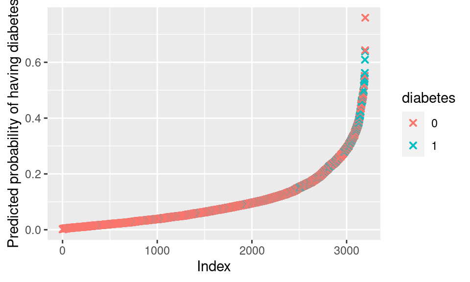

```r
draw_predicted_prob(m.final, diab.subset$train, "diabetes")
```

Assess model accuracy by comparing predicted outcome at test locations (20% of the dataset).

```r
cross_validation(m.final, diab.subset$test, "diabetes", 0.3)
```

```
## Confusion Matrix and Statistics
##
##           Reference
## Prediction   0   1
##          0 701  49
##          1  39  10
##
##                Accuracy : 0.8899
##                  95% CI : (0.8661, 0.9107)
##     No Information Rate : 0.9262
##     P-Value [Acc > NIR] : 0.9999
##
##                   Kappa : 0.1267
##
##  Mcnemar's Test P-Value : 0.3374
##
##             Sensitivity : 0.16949
##             Specificity : 0.94730
##          Pos Pred Value : 0.20408
##          Neg Pred Value : 0.93467
##              Prevalence : 0.07384
##          Detection Rate : 0.01252
##    Detection Prevalence : 0.06133
##       Balanced Accuracy : 0.55839
##
##        'Positive' Class : 1
##
```

- `Accuracy`: proportion of correct predictions out of all predictions made.
- `Kappa`: agreement between predicted and actual values, adjusted for chance. The coefficient ranges from -1 to 1, with 1 indicating perfect agreement and 0 indicating agreement due to change.
- `Sensitivity`: proportion of true positives out of all actual positives (Positives are defined based on the “Positive class” specified at the bottom of the summary).
- `Specificity`: proportion of true negatives out of all actual negatives.

For the model for diabetes, we obtain a high accuracy (88.9%) but we have a low sensitivity and a low Kappa coefficients. We can only identified 17% of the actual positive cases.